# Take Home Exercise 4

Take Home Exercise 4 is to reveal the daily routines of two selected participant of the city of Engagement, Ohio USA.  
[`ViSIElse`](https://cran.r-project.org/web/packages/ViSiElse/index.html), a graphical tool to visualize behavioural observations, and other appropriate visual analytics methods will be used.

Huang Yaping https://www.linkedin.com/in/huang-yp/ (School of Computing and Information Systems)https://scis.smu.edu.sg/  
2022-05-19

### Loading R packages

```r
packages = c('scales', 'viridis',
             'lubridate', 'ggthemes',
             'gridExtra', 'tidyverse',
             'readxl', 'knitr',
             'data.table', 'ViSiElse')

for (p in packages){
  if(!require(p, character.only = T)){
    install.packages(p)
  }
  library(p, character.only = T)
}
```

## 1. Explore Recreatinal Pattern

### 1.1 Data Wrangling for Recreation Pattern Across Weekday and Hour

##### Note: only the first 10 activity logs files are combined and analyzed here.

logs_recreation <- read_csv(“data/logs1_10.csv”) %>% select(timestamp, participantId, currentMode) %>% filter(currentMode == “AtRecreation”) %>% mutate(wkdays = weekdays(ymd_hms(timestamp, quiet = TRUE))) %>% mutate(hour = hour(ymd_hms(timestamp, quiet = TRUE))) %>% count(wkdays, hour) %>% ungroup() %>% na.omit()

write_csv(logs_recreation,‘data/logs_recreation.csv’ )

### 1.2. Plot Calendar Heat Map for Recreation Pattern

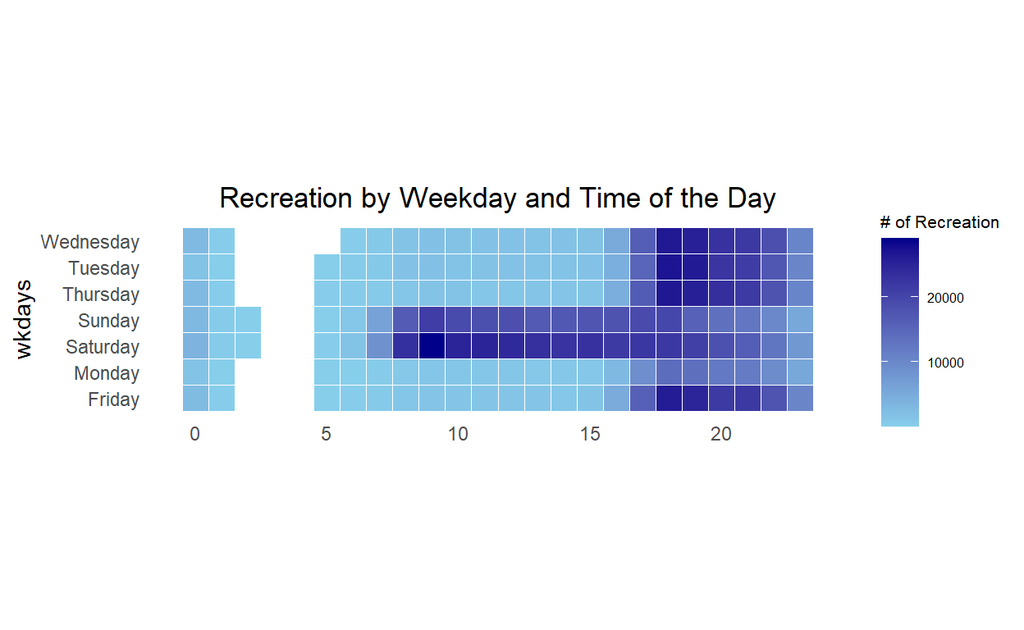

```r
logs_recreation <- read_csv("data/logs_recreation.csv")
ggplot(logs_recreation, aes(hour, wkdays, fill = n))+
  geom_tile(color = "white", size = 0.1)+
  theme_tufte(base_family = "Helvetica")+
  coord_equal()+
  scale_fill_gradient(name = "# of Recreation",
                       low = "sky blue",
                       high = "dark blue")+
  labs(x = NULL, Y= NULL,
       title = "Recreation by Weekday and Time of the Day")+
  theme(axis.ticks = element_blank(),
      plot.title = element_text(hjust = 0.5),
      legend.title = element_text(size = 8),
      legend.text = element_text(size = 6) )
```

logs_sleep <- read_csv(“data/logs1_10.csv”) %>% select(timestamp, participantId, sleepStatus) %>% filter (participantId == 0) %>% mutate(date = as.IDate(ymd_hms(timestamp, quiet = TRUE))) %>% mutate(minutes = hour(ymd_hms(timestamp))*60+minute(ymd_hms(timestamp))) %>% group_by(date, sleepStatus) %>% summarise(time = min(minutes)) %>% pivot_wider(names_from = sleepStatus, values_from = time)

logs_mode <- read_csv(“data/logs1_10.csv”) %>% select(timestamp, participantId, currentMode) %>% filter (participantId == 0) %>% mutate(date = as.IDate(ymd_hms(timestamp, quiet = TRUE))) %>% mutate(minutes = hour(ymd_hms(timestamp))*60+minute(ymd_hms(timestamp))) %>% group_by(date, currentMode) %>% summarise(time = min(minutes)) %>% pivot_wider(names_from = currentMode, values_from = time)

logs_hungry <- read_csv(“data/logs1_10.csv”) %>% select(timestamp, participantId, hungerStatus) %>% filter (participantId == 0) %>% mutate(date = as.IDate(ymd_hms(timestamp, quiet = TRUE))) %>% mutate(minutes = hour(ymd_hms(timestamp))*60+minute(ymd_hms(timestamp))) %>% group_by(date,hungerStatus) %>% summarise(time = min(minutes)) %>% pivot_wider(names_from = hungerStatus, values_from = time)

daily_life_p <- left_join(logs_sleep, logs_mode) daily_life <- left_join(daily_life_p, logs_hungry) write_csv(daily_life, “data/daily_life.csv”)

### 2.2 Plot Daily Routine for participantId = 0 with visielse()

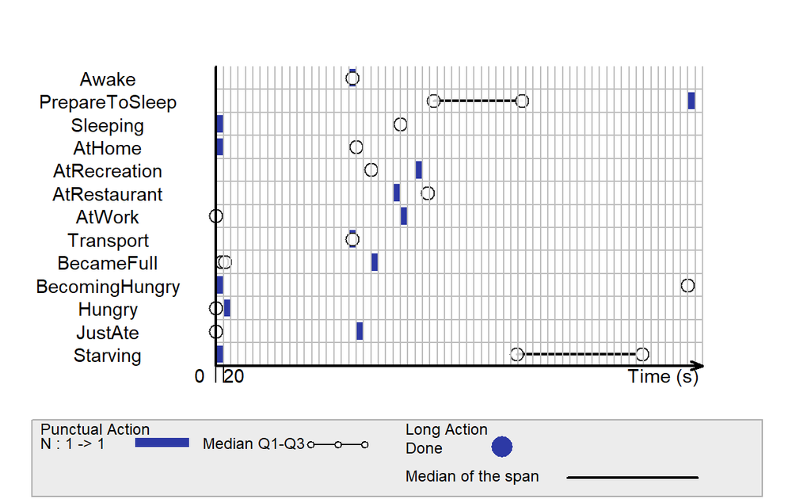

[output not shown]

```r
daily_life <- read_csv("data/daily_life.csv")
visielse(daily_life)
```

### 2.3 Plot Daily Routine for participantId = 500 with visielse()

##### Note that daily_life1.csv was created by using same code in 2.1 with participantId set to 500.

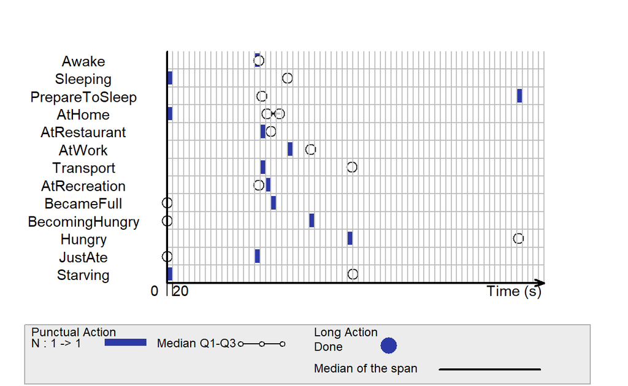

[output not shown]

```r
daily_life1 <- read_csv("data/daily_life1.csv")
visielse(daily_life1)
```